# Inferring species interactions from temporal data

2017-03-06

## Inference on species interactions is often very indirect

- Species interactions can be important for community and ecosystem structure from local to macroecological scales
- Competition is fluid, but studies often focus on only a few species at a time.
- Inference about competitive processes made with data that doesn't have a temporal dimension

## Inference on species interactions is often very indirect

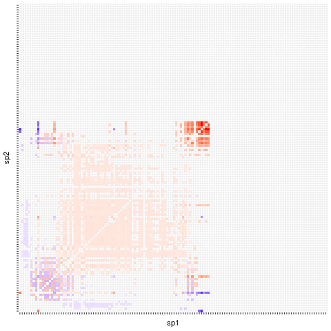

## Inference on processes from static data is HARD

- Are communities in equilibrium? If not, results are biased.
- Zero inflation often biases results or lowers statistical power, because joint-absences hard to exclude from models.
- Missing environmental covariates cause correlations in residual occurrences.
- Models have a gazillion parameters and complicated structure

## Inference on processes from static data is HARD

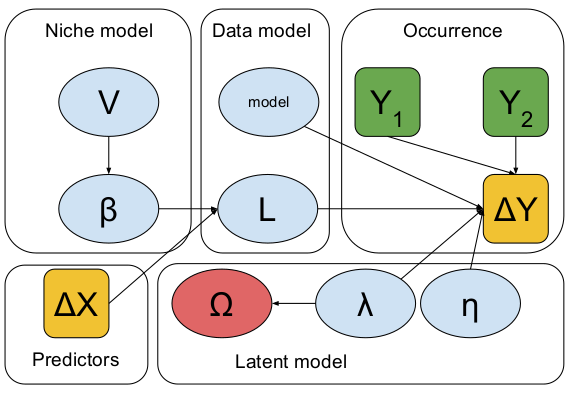

## Idea

- Model correlations in abundance *changes* between species after controlling for the environment.
- Data from (permanent) plots at two points in time
- Significance testing by permutation or with JSDM

## Idea

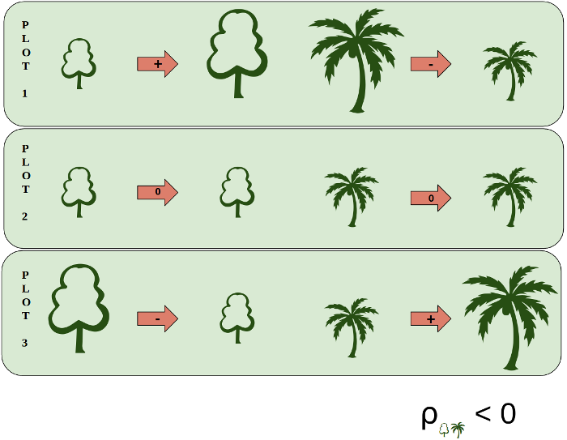

## Advantages

- No need to estimate regression coefficients for environmental variables that can be assumed to have remained constant in time
- Ability to remove double-zero occurences without losing information
- Paired study design relaxes some model restrictions related to data distribution
- Inference about the full competitive interaction network instead of a small group of species
- **Temporally explicit data enables direct inference about processes**

## Example

- Simulated data: 100 species, 500 permanent plots, 2 temporal replicates
- Species increase and decrease jointly: correlation structure
- 2 scenarios, no missing data, half missing data
- Missing data corresponds to events where species was absent at both times.

## No missing data, significant errors

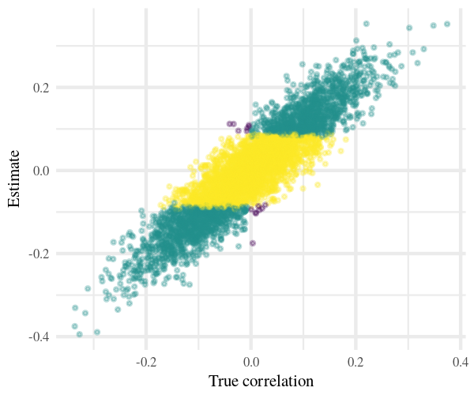

## Half missing, significant errors

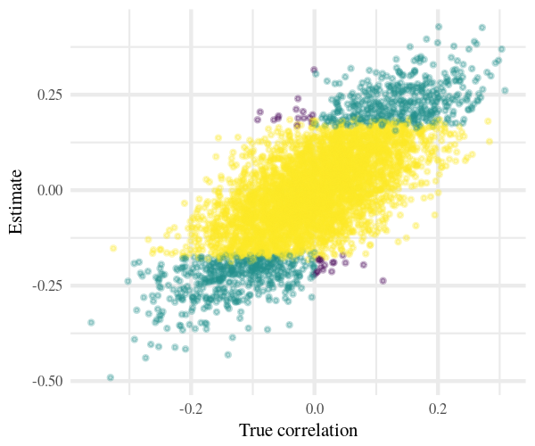

## How strong is that?

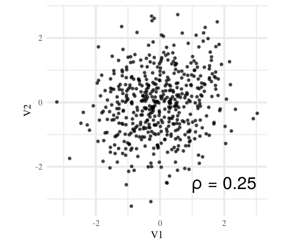

## Outline for method

1. Calculate expected occurrence change between t1 and t<sub>2</sub>
   - If changes are expected to be similar over study area, only intercepts needed
   - Otherwise include environmental covariates which influence trend
2. Calculate correlations among deviations from expected change
3. Permutate columns of n s abundance change matrix to produce null distribution of correlations
4. Compare observed correlations to e.g. 0.025 and 0.975 quantiles of null distribution

## I lack data. Let's collaborate?

[Konsta Happonen](https://twitter.com/koalha)

PhD candidate

University of Helsinki

Department of Geopraphy

[BioGeoClimate Modelling Lab](http://helsinki.fi/biogeoclimate)

konsta.happonen@helsinki.fi

## References

Damgaard, Christian, and Jacob Weiner. 2017. “Its About Time: A Critique of Macroecological Inferences Concerning Plant Competition.” Trends in Ecology & Evolution 32. doi:10.1016/j.tree.2016.12.001.

Harris, David J. 2016. “Inferring Species Interactions from Co-Occurrence Data with Markov Networks.” Ecology 97. doi:10.1002/ecy.1605.

Maestre, Fernando T., Ragan M. Callaway, Fernando Valladares, and Christopher J. Lortie. 2009. “Refining the Stress-Gradient Hypothesis for Competition and Facilitation in Plant Communities.” Journal of Ecology 97. doi:10.1111/j.1365-2745.2008.01476.x.

Ovaskainen, Otso, Nerea Abrego, Panu Halme, and David Dunson. 2016. “Using Latent Variable Models to Identify Large Networks of Species-to-Species Associations at Different Spatial Scales.” Edited by David Warton. Methods in Ecology and Evolution 7. doi:10.1111/2041-210x.12501.